# Twitter Final Writeup

Jonah Klein-Barton, Aaron Brezel, Alex Petri

May 9, 2018

## Project Overview

Our group was tasked with stealing twitter data from mayors of American cities over 30,000 people, putting it into a database, and analyzing it. The database can be found here: https://wustl.app.box.com/file/289481874492. In addition, we looked at some ways of visualizing trends we found within the data, as shown below.

## **Visualization of data**

## Account Verification

When thinking about mayoral twitter accounts for large cities, one migh expect them to be officially verified by twitter. However, very few are, as seen in the plot below. Out of 719 accounts in this data set, only 65 were verified.

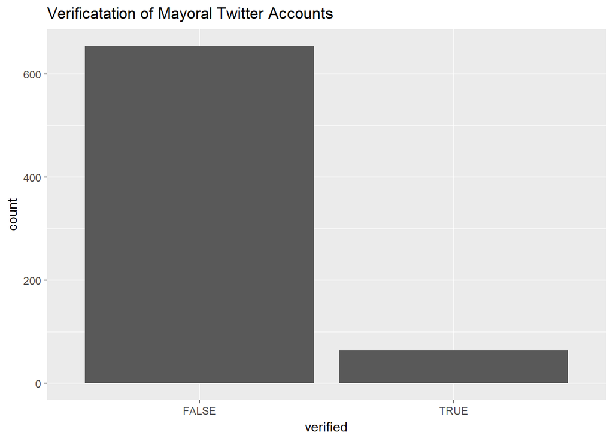

```
##    Mode   FALSE    TRUE
## logical     654      65
```

## Default Language

While the vast majority of twitter accounts looked at were set to English (“en”) as a default language, there were two accounts which had Spanish (“es”) as a default. These accounts belonged to Alberto Santos (@alberto_santos) and Carlos Gerlach (@CarlosGerlachR). However, after looking at these accounts I believe there may have been a data entry issue in the main data set.

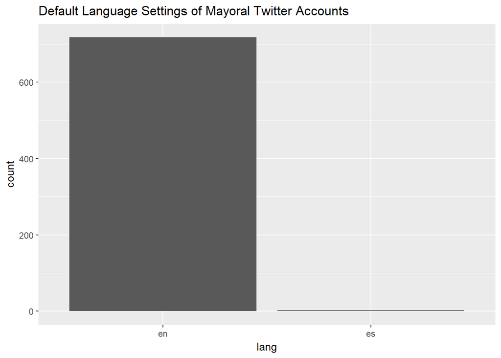

```
##  en  es
## 717   2
```

## Distribution of # of Followers

To get a sense of the wildly different amount of followers some of these accounts have, we plotted the frequency of different amounts of followers. We can see that the logs of the number of followers follow an apporximately normal distribution, centered around log(followers) = 7, or e^7 == ~1096.

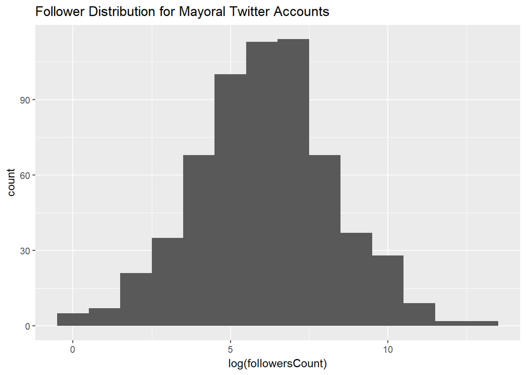

## Correlation between Tweets and Followers

By plotting the number of followers a mayor has against both how often they tweet and the population of their city, it seems as though there is more of a correlation between how often they tweet, rather than how big the city is. There are probably many other factors at play here, but it’s interesting to note that one thing this does tell us is that people will not neccecarily follow their mayor’s twitter unless it’s actually giving them information.

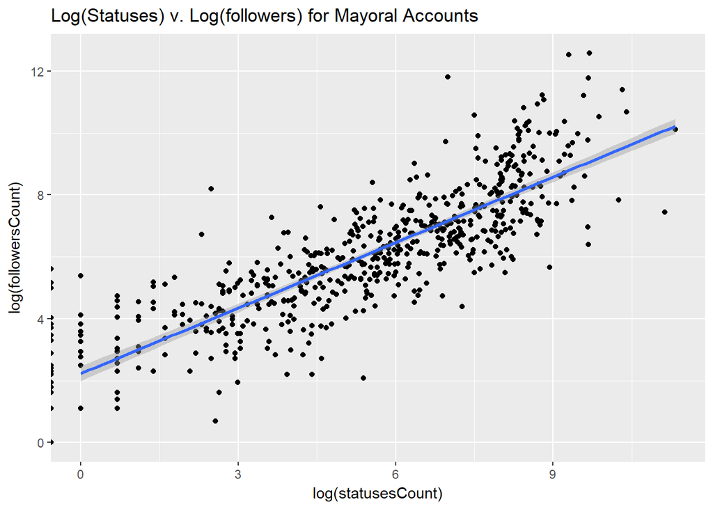

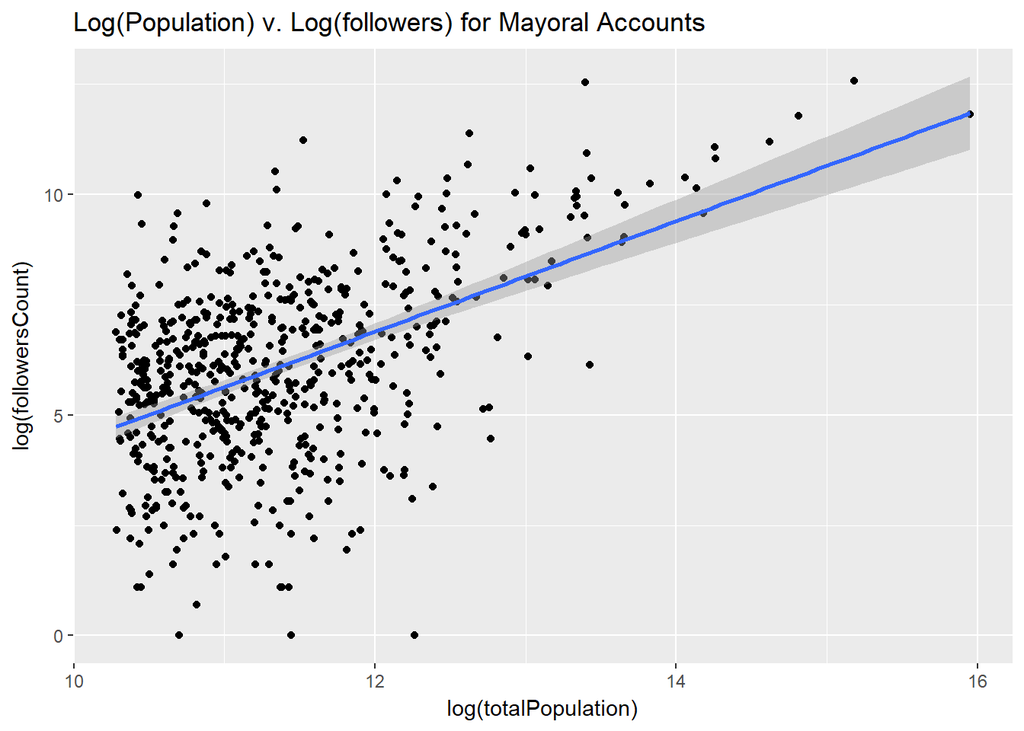

## Correlation between Millenial Make-up and Mayoral Responsiveness

Here we look at responsiveness for a mayor as the percent of that mayor’s millenial (categorized here as percent of the population 34 or below) increases, and vice verse for as the mayors non-millenial population increases. Generally, we find that responiveness increases as millenial composition increases and decreases as non-millenial composition increases. However, note the R^2 values, which show these variables account for very little of the model.

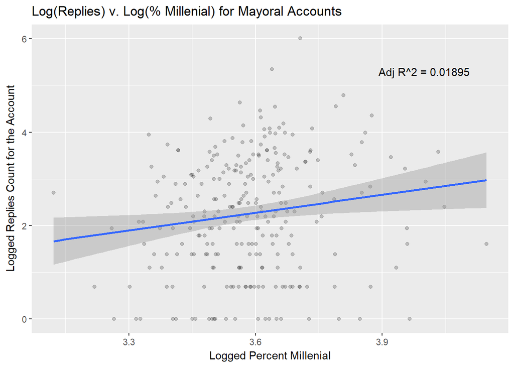

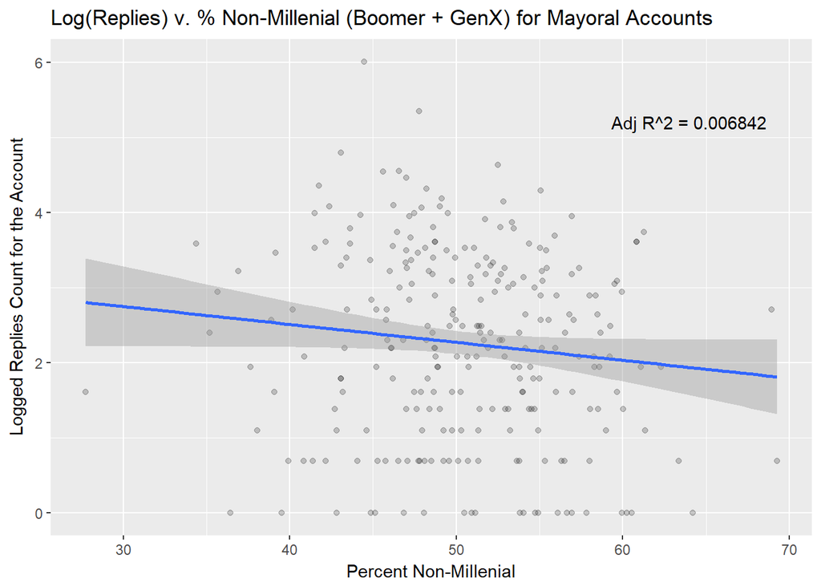

## Correlation between General Mayor Twitter Activity and Mayoral Responsiveness

It seems the best predictor of how often a mayor will respond to others is how often they tweet generally. Here we see a strong increase for replies as statuses increase, and the R^2 value shows this accounts for a large portion of the model.

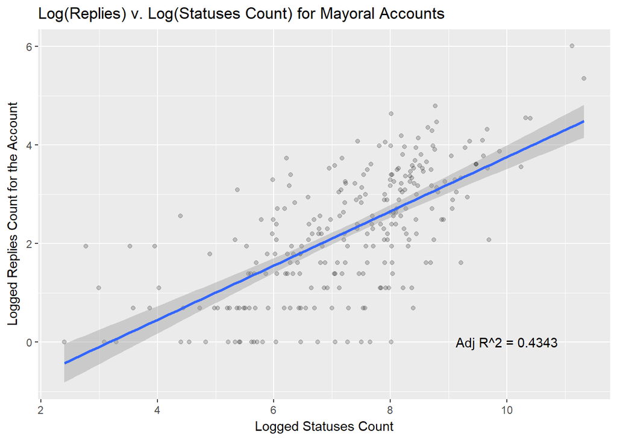